# SMekala_Assign10

Sekhar Mekala

Monday, October 26, 2015

Let us create the page rank transition matrix for the given 6 pages map:

```r
A = matrix(c(0,0,1/4,0,0,0,
             1/2,0,1/4,0,0,0,
             1/2,1,0,0,0,1/2,
             0,0,0,0,1/2,1/2,
             0,0,1/4,1/2,0,0,
             0,0,1/4,1/2,1/2,0
             ),byrow = T, ncol = 6)

print(A)
```

```
##      [,1] [,2] [,3] [,4] [,5] [,6]
## [1,]  0.0    0 0.25  0.0  0.0  0.0
## [2,]  0.5    0 0.25  0.0  0.0  0.0
## [3,]  0.5    1 0.00  0.0  0.0  0.5
## [4,]  0.0    0 0.00  0.0  0.5  0.5
## [5,]  0.0    0 0.25  0.5  0.0  0.0
## [6,]  0.0    0 0.25  0.5  0.5  0.0
```

Introducing the decay matrix:

```r
#B = (A * 0.85) + matrix(rep((0.15/6),36),ncol=6)
B = (A * 0.85) + (0.15/6)

print(B)
```

```
##       [,1]  [,2]   [,3]  [,4]  [,5]  [,6]
## [1,] 0.025 0.025 0.2375 0.025 0.025 0.025
## [2,] 0.450 0.025 0.2375 0.025 0.025 0.025
## [3,] 0.450 0.875 0.0250 0.025 0.025 0.450
## [4,] 0.025 0.025 0.0250 0.025 0.450 0.450
## [5,] 0.025 0.025 0.2375 0.450 0.025 0.025
## [6,] 0.025 0.025 0.2375 0.450 0.450 0.025
```

Let us create the rank matrix:

```r
r = c(1/6,1/6,1/6,1/6,1/6,1/6)
```

We will be looking at the following 3 methods to perform page ranking:

- Getting the page rank by means of convergence
- Getting the page rank by means eigen values/eigen vectors
- Using **igraph** package

## Manual computation

Let us repeat the matrix multiplication $B X r$, till the result converges (with an acceptable error of 0.00000000001). If the result does not converge in 250 iterations, then we will stop the multiplication, and suggest the user to manually inspect why the result does not converge.

```r
C = rep(0.00000000001,6)
#C = rep(0,6)

for (i in 1:251)
{  T1 = B%*% r
   B = B %*% B
   T2 = B %*% r
   if (all(abs(T1 - T2) <= C)) {
     print(T2)
     break
      }
}
```

```
##            [,1]
## [1,] 0.07735886
## [2,] 0.11023638
## [3,] 0.24639464
## [4,] 0.18635389
## [5,] 0.15655927
## [6,] 0.22309696
```

```r
if(i == 251) {
  print("Check why the multiplication does not converge!!")
} else {
cat("The result converges at: ", i," iteration","\n")
print("The page ranks are displayed below:")
df <- data.frame(page=1:6,rank=T2)
df[order(df[,2],decreasing=T),]
}
```

```
## The result converges at:  7  iteration
## [1] "The page ranks are displayed below:"
```

```
##   page       rank
## 3    3 0.24639464
## 6    6 0.22309696
## 4    4 0.18635389
## 5    5 0.15655927
## 2    2 0.11023638
## 1    1 0.07735886
```

## Using eigen values/eigen vectors

Let us get the eigen value and vector of the B matrix. We need to reset this back.

```r
B = (A * 0.85) + (0.15/6)
e <- eigen(B)
print(e)
```

```
## $values
## [1]  1.0000000+0.000000i  0.5063824+0.000000i -0.4250000+0.000000i
## [4] -0.4250000-0.000000i -0.2531912+0.108131i -0.2531912-0.108131i
##
## $vectors
##               [,1]          [,2]                        [,3]
## [1,] -0.1784825+0i -0.2229218+0i  7.871735e-16-8.103903e-09i
## [2,] -0.2543376+0i -0.4100171+0i -1.430459e-16-0.000000e+00i
## [3,] -0.5684822+0i -0.5312173+0i  0.000000e+00+1.620781e-08i
## [4,] -0.4299561+0i  0.5312173+0i -7.071068e-01+0.000000e+00i
## [5,] -0.3612138+0i  0.2229218+0i  7.071068e-01-0.000000e+00i
## [6,] -0.5147297+0i  0.4100171+0i  0.000000e+00-8.103903e-09i
##                             [,4]                  [,5]
## [1,]  7.871735e-16+8.103903e-09i  0.3622630+0.1547126i
## [2,] -1.430459e-16+0.000000e+00i -0.0582205-0.2845608i
## [3,]  0.000000e+00-1.620781e-08i -0.5103578+0.0000000i
## [4,] -7.071068e-01+0.000000e+00i  0.5103578+0.0000000i
## [5,]  7.071068e-01+0.000000e+00i -0.3622630-0.1547126i
## [6,]  0.000000e+00+8.103903e-09i  0.0582205+0.2845608i
##                       [,6]
## [1,]  0.3622630-0.1547126i
## [2,] -0.0582205+0.2845608i
## [3,] -0.5103578-0.0000000i
## [4,]  0.5103578+0.0000000i
## [5,] -0.3622630+0.1547126i
## [6,]  0.0582205-0.2845608i
```

From the above display, we can conclude that the eigen vector obtained for eigen value of 1 is given below:

```r
print(Re(e$vectors[,1]))
```

```
## [1] -0.1784825 -0.2543376 -0.5684822 -0.4299561 -0.3612138 -0.5147297
```

Let us make these values to sum up to 1:

```r
rank <- Re(e$vectors[,1])/sum(Re(e$vectors[,1]))
```

Let us print the result in a better format:

```r
df <- data.frame(pages = 1:6, rank = rank)
print(df[order(df[,2],decreasing=T),])
```

```
##   pages       rank
## 3     3 0.24639464
## 6     6 0.22309696
## 4     4 0.18635389
## 5     5 0.15655927
## 2     2 0.11023638
## 1     1 0.07735886
```

## Using igraph package

Using “igraph” package to find the page rank.

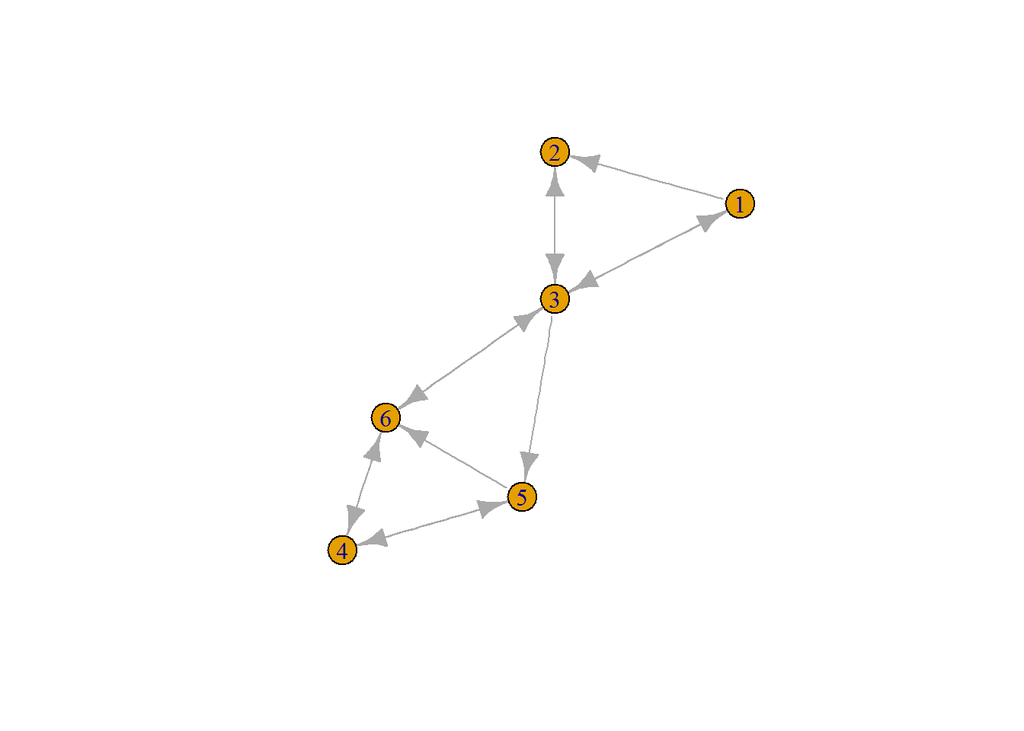

```r
library('igraph')
g <- graph(c(1,2, 1,3, 2,3, 3,1, 3,2,3, 6, 3,5,6,3,5,6,6,4,4,6,5,4,4,5),n=6)
plot(g)
```

```r
rank <- page.rank(g)$vector
page <- 1:6

df <- data.frame(page=page,rank = rank)
df[order(df[,2],decreasing=T),]
```

```
##   page       rank
## 3    3 0.24639464
## 6    6 0.22309696
## 4    4 0.18635389
## 5    5 0.15655927
## 2    2 0.11023638
## 1    1 0.07735886
```

## Conclusion

The page ranks obtained manually (through convergence or eigen values/vectors), and the page ranks obtained through **igraph** are the same.

```
                                                  ~~~**End of Assignment**~~~
```